# 20221002：パワーウィンドウが壊れた

Takala

愛車のパワーウィンドウが壊れた． 窓が空いたまま閉まらない状態となってしまった．

ディーラーに見せたところ，モーターが焼き切れていて部品交換するしかないとのこと．．． 部品と工賃込みで2万円の出費とかなり痛い． しかも，納品日の関係で1週間ほどは空いたまま過ごす必要がある．

運転中はまだしも，駐車しているときに不安なので，簡単に窓を自作した．

素材名をちゃんと記録しておけばよかったが，ホームセンターで適当に見つけた カーボン？なんとかという素材．アクリルより安価だがかなり剛性があり，加工もしやすかった．

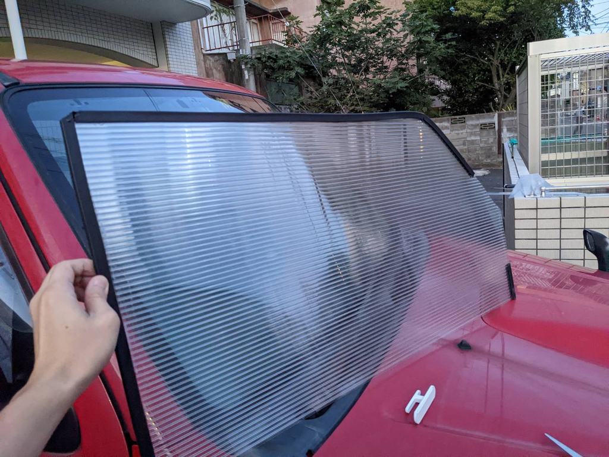

自作窓

適当な長さに切りだし，断面はゴムでコーティングした．

けっこういい感じにできた気がする．

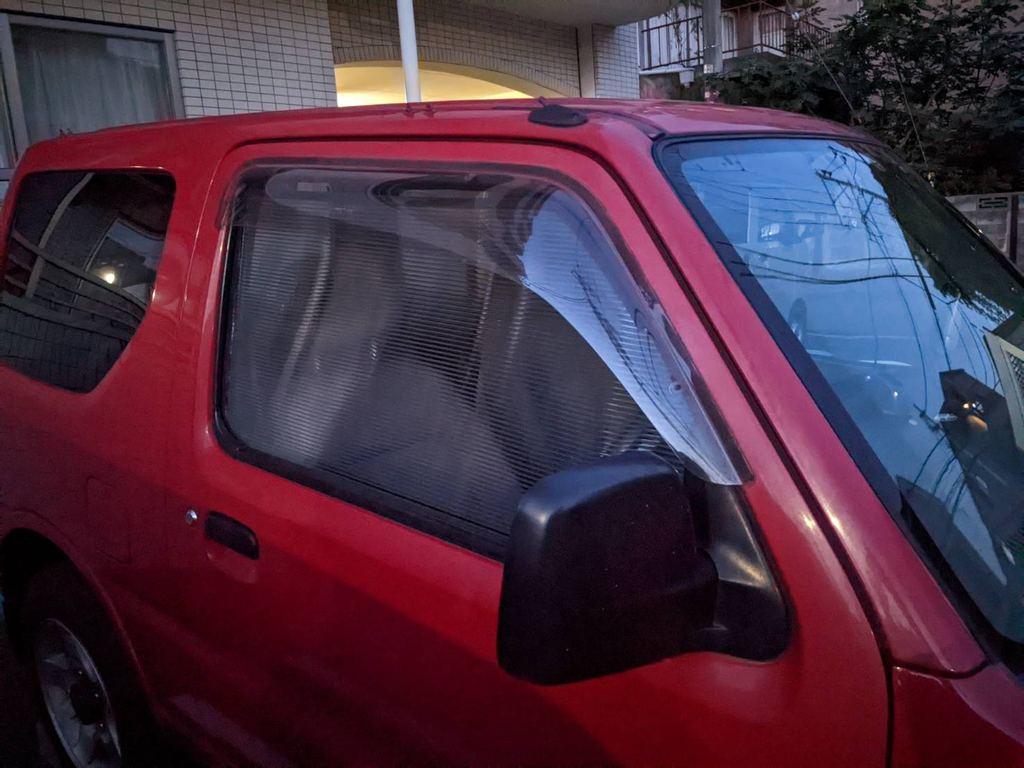

はめ込んだ状態

もはや．修理せずにこれでいいかもしれない． ただ，車の窓ガラスは強度や透過率などの規格が法律で定められており，運転席のスモークなどは厳禁なので， このまま走行はできない．

走行中が雨風受けっぱなしというわけにもいかないので2万円払いましょう．．．